# Time Series: A First Course with Bootstrap Starter

# Lesson 29: Block Bootstrap

- We now look at *block bootstrap methods*, which is similar in spirit to subsampling.
- We take sub-spans of the time series, and then patch them together to generate a synthetic time series that functions as our pseudo-sample.

## Paradigm 12.8.2. Block Bootstrap for the Sample Mean

- Suppose we have a stationary time series $\{ X_t \}$.
- Suppose $\theta$ is the mean, and $\widehat{\theta}$ is the sample mean. Then
  $$J_n (x) = {\mathbb P} [ \sqrt{n} (\widehat{\theta} - \theta) \leq x] \rightarrow J(x),$$
  where $J(x) = \Phi (x/\sigma_{\infty})$.
- Let $b$ be small relative to $n$, as in the subsampling method.
- Divide the sample into $Q = n-b+1$ overlapping blocks.
- We want to construct a length $n$ pseudo-sample from length $b$ blocks, so we require $k = n/b$ such blocks.
- Idea: randomly draw from the $Q$ blocks, and then paste them together!
- Denote those $Q$ blocks of random variables as $B_1, \ldots, B_Q$.
1. For $1 \leq j \leq M$, draw $B_1^{*(j)}, \ldots, B_k^{*(j)}$ randomly (with replacement) from the set of available blocks $B_1, \ldots, B_Q$.
2. Concatenate for each $j$ those draws, obtaining the $j$th pseudo-series $X_1^{*(j)}, \ldots, X_n^{*(j)}$.
3. Compute the statistic on each pseudo-series, denoted $\widehat{\theta}_n^{*(j)}$.
4. We estimate $J_n (x)$ with
   $$\frac{1}{M} \sum_{j=1}^M 1_{ \{ \sqrt{n} (\widehat{\theta}_n^{*(j)} - \widehat{\theta}_n ) \leq x \} }.$$
- Just like subsampling, we insert $\widehat{\theta}_n$ for $\theta$.
- There is a variant called the *tapered block bootstrap*, where observations at the edge of a block $B_k$ get down-weighted.

## Exercise 12.33. Block Bootstrap for the Mauna Loa Mean

- Consider annual differences of the logged Mauna Loa CO2 time series.
- We want to estimate the mean using block bootstrap. So we apply the above method to obtain the cdf of the centered statistic.

```r
mau <- read.table("mauna.dat",header=TRUE,sep="")
mau <- ts(mau,start=1958,frequency=12)
mau.gr <- 1000*diff(log(mau),lag=12)
n <- length(mau.gr)
mau.mean <- mean(mau.gr)
```

- The sample mean (after rescaling) is 3.6382049.
- First try $b = \sqrt{n}$ and $M = 10^5$.
- We can also try $b = n^{1/3}$ and $b = n^{2/3}$ by rerunning the code chunk.

```r
# Make choice of b, and then run
b <- ceiling(sqrt(n))
#b <- ceiling(n^(1/3))
#b <- ceiling(n^(2/3))

k <- ceiling(n/b)
Q.big <- n - b + 1
monte.roots <- NULL
Monte <- 100000
for(i in 1:Monte)
{
    monte.sample <- NULL
    for(j in 1:k)
    {
        boot.index <- sample(Q.big,size=1)
        monte.sample <- c(monte.sample,mau.gr[seq(boot.index,boot.index+b-1)])
    }
    monte.sample <- monte.sample[1:n]
      monte.root <- mean(monte.sample) - mau.mean
    monte.roots <- c(monte.roots,monte.root)
}
#hist(monte.roots)
interval <- c(sort(monte.roots)[floor(.025*Monte)],sort(monte.roots)[floor(.975*Monte)])
```

- The $95 \%$ confidence interval based on the bootstrap is [3.0450196,4.1734786].
- We plot the bootstrap edf.

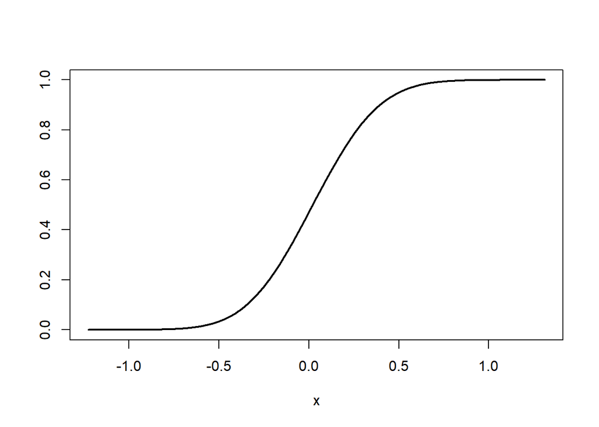

[figure not shown]

```r
plot(sort(monte.roots),seq(1,Monte)/Monte,type="l",xlab="x",ylab="",lwd=2)
```